# Task 2

Mikhail Zhilkin

2017-10-01

```r
library(scales)
library(tidyverse)
```

Import the data set:

```r
dailyplay <- readxl::read_excel("Task22parts-2hr30mins[1].xlsx", sheet = 1)
promotions <- readxl::read_excel("Task22parts-2hr30mins[1].xlsx", sheet = 2)
```

Aggregated data:

```r
df <- dailyplay %>%
    group_by(Date) %>%
    summarise(Players = n(), Revenue = sum(Revenue)) %>%
    inner_join(promotions) %>%
    mutate(
        Dayofweek = weekdays(Date),
        Promo = ifelse(is.na(Promo), " ", Promo)
    )
```

```r
df
```

| Date | Players | Revenue | Promo | Dayofweek |
| --- | --- | --- | --- | --- |
| 2016-10-01 | 707 | 5211 |  | Saturday |
| 2016-10-02 | 1455 | 10386 | A | Sunday |
| 2016-10-03 | 1520 | 12475 | B | Monday |
| 2016-10-04 | 1726 | 14414 |  | Tuesday |
| 2016-10-05 | 2134 | 20916 |  | Wednesday |
| 2016-10-06 | 1316 | 12996 | B | Thursday |
| 2016-10-07 | 1287 | 11929 | B | Friday |
| 2016-10-08 | 1548 | 10072 |  | Saturday |
| 2016-10-09 | 1448 | 12016 | B | Sunday |
| 2016-10-10 | 1362 | 9067 |  | Monday |

[output cut: 172 more lines]

Simple linear regression model:

```r
fit <- df %>% lm(Revenue ~ Dayofweek + Promo + Players, .)
```

```r
summary(fit)
```

```
Call:
lm(formula = Revenue ~ Dayofweek + Promo + Players, data = .)

Residuals:
    Min      1Q  Median      3Q     Max
-4492.6 -1280.6  -258.3   821.4 11187.2

Coefficients:
                     Estimate Std. Error t value             Pr(>|t|)
(Intercept)        -4694.3628   741.3038  -6.333        0.00000000203 ***
DayofweekMonday      500.3965   599.2206   0.835              0.40483
DayofweekSaturday    -16.0131   599.0499  -0.027              0.97871
DayofweekSunday      -13.9592   598.0471  -0.023              0.98141
DayofweekThursday   1003.9474   598.3906   1.678              0.09521 .
DayofweekTuesday    1445.3934   675.7331   2.139              0.03385 *
DayofweekWednesday  1842.6579   629.2399   2.928              0.00387 **
PromoA              1622.1725   389.5763   4.164        0.00004938533 ***
PromoB              4272.3819   393.8384  10.848 < 0.0000000000000002 ***
Players                9.1538     0.3998  22.895 < 0.0000000000000002 ***
---
Signif. codes:  0 *** 0.001 ** 0.01 * 0.05 . 0.1   1

Residual standard error: 2150 on 172 degrees of freedom
Multiple R-squared:  0.873, Adjusted R-squared:  0.8664
F-statistic: 131.4 on 9 and 172 DF,  p-value: < 0.00000000000000022
```

**a. What is the predicted revenue for the below days?**

```r
a <- tibble(
    Dayofweek = c("Monday", "Tuesday", "Wednesday", "Thursday", "Friday", "Saturday", "Sunday"),
    Promo = c(" ", "A", " ", "B", "A", "B", " "),
    Players = c(3, 4, 4, 5, 6, 6, 7) * 1000
)
```

```r
cbind(a, predict.lm(fit, a))
```

|  | Dayofweek | Promo | Players | predict.lm(fit, a) |
| --- | --- | --- | --- | --- |
| 1 | Monday |  | 3000 | 23267.44 |
| 2 | Tuesday | A | 4000 | 34988.41 |
| 3 | Wednesday |  | 4000 | 33763.50 |
| 4 | Thursday | B | 5000 | 46350.98 |
| 5 | Friday | A | 6000 | 51850.62 |
| 6 | Saturday | B | 6000 | 54484.82 |
| 7 | Sunday |  | 7000 | 59368.29 |

**b. Which promotion do you think performs better and why?**

From the model summary above, it’s clear that Promo B has a significantly higher positive impact on revenue. This can easily be verified by predicting revenue for Promo A and Promo B with everything else being equal. Indeed, prediction for Promo B is much higher:

```r
predict.lm(
    fit,
    tibble(
        Dayofweek = rep("Monday", 2),
        Promo = c("A", "B"),
        Players = rep(1000, 2)
    )
)
```

```
       1        2
6582.008 9232.218
```

**c. What are the 95% confidence intervals to your revenue predictions?**

Last two columns contain lower/upper bounds of the confidence interval at the default level of 95%:

```r
cbind(a, predict.lm(fit, a, interval = "confidence"))
```

|  | Dayofweek | Promo | Players | fit | lwr | upr |
| --- | --- | --- | --- | --- | --- | --- |
| 1 | Monday |  | 3000 | 23267.44 | 21795.40 | 24739.48 |
| 2 | Tuesday | A | 4000 | 34988.41 | 33285.84 | 36690.98 |
| 3 | Wednesday |  | 4000 | 33763.50 | 31860.31 | 35666.70 |
| 4 | Thursday | B | 5000 | 46350.98 | 43437.08 | 49264.87 |
| 5 | Friday | A | 6000 | 51850.62 | 48149.67 | 55551.57 |
| 6 | Saturday | B | 6000 | 54484.82 | 50877.34 | 58092.30 |
| 7 | Sunday |  | 7000 | 59368.29 | 54834.92 | 63901.66 |

**d. Plot the residuals and explain what they tell us about the model**

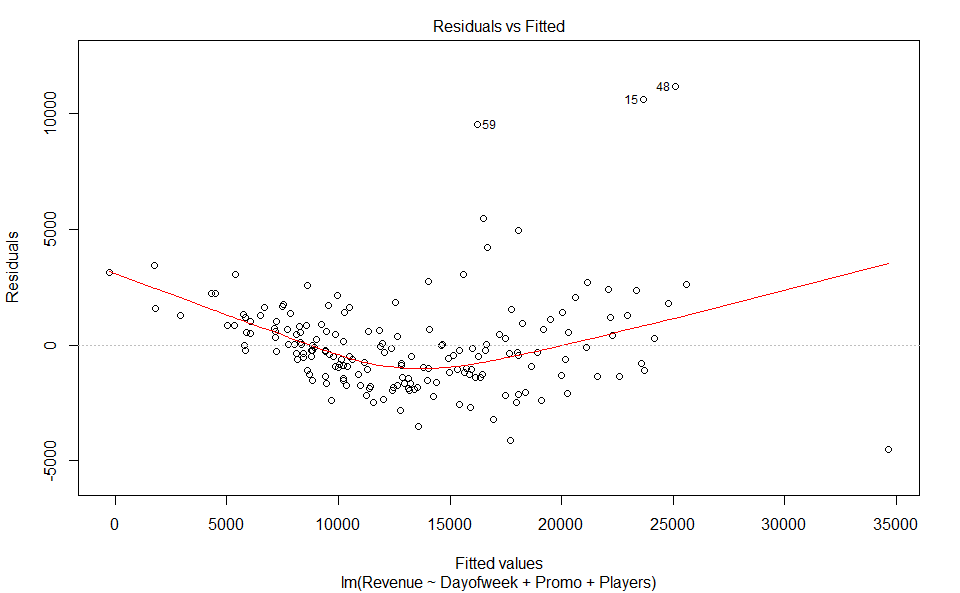

```r
plot(fit, which = 1)
```

We can achieve better results with a slightly more sophisticated model:

```r
fit2 <- df %>% lm(Revenue ~ Dayofweek * Promo * Players + 0, .)
```

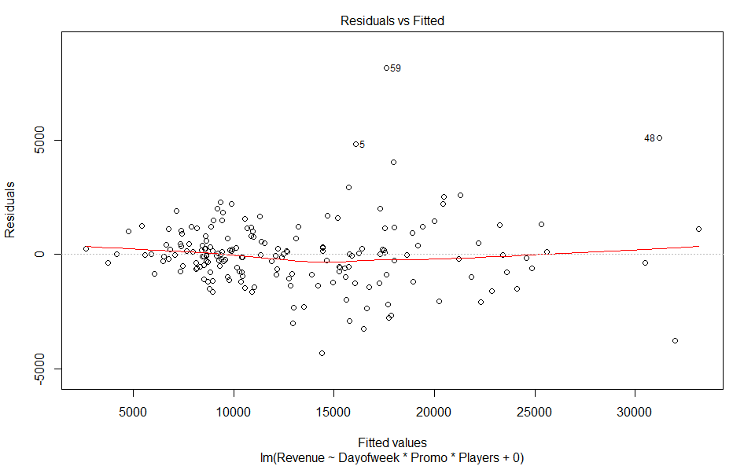

```r
plot(fit2, which = 1)
```

**e. With more time and data would you approach this problem differently?**

Things I’d consider doing:

- Take a close look at outliers — days for which prediction is way off. Can they be explained? Do they suggest any variables we might want to include in the model?
- Player segmentation (e.g. low/medium/ high spenders) — as another variable in the model, or even separate model for each segment.
- In addition to the promo running on a given day, take into account promotional activity *prior* to that day. The impact of the first day of a promotion campaign can be quite different from that of day 5.